# **secrRFS** - SECR random field simulator

Murray Efford

2023-11-12

# Introduction

Spatial capture–recapture estimates population density from a sample of $n$ marked individuals detected at an array of detectors. Density is treated as the intensity of a point process where each point is the activity centre of an individual. Overdispersion of $n$ relative to the expected variance (Poisson or binomial) leads to poor coverage of confidence intervals for density. This document demonstrates the use of **secrRFS** to simulate overdispersion of $n$ from a known detection model and generating process for the AC.

The generating process is assumed to be a Cox process i.e. an inhomogeneous Poisson process (IHPP) in which the intensity surface varies stochastically between realisations (Mller and Waagepetersen 2004). The Thomas cluster process is treated as a Cox process with intensity surface defined by each realisation of parent points. The conditional case (fixed number in known area $A$) is not handled.

The available generating processes are

| Generating process | Source function | secrRFS function | Parameters |
| --- | --- | --- | --- |
| Binary habitat mosaic | secr::randomHabitat | randomDensity | D, p, A |
| Log-gaussian random field | RandomFields::RFsimulate | randomGaussian | D, var, scale |
| Thomas cluster process | spatstat.random::rThomas | randomParents | D, mu, scale |

**secrRFS** requires version 4.6.5 or later of package **secr** (Efford 2023). Packages RandomFields (Schlather et al. 2015)[^1] and spatstat (Baddeley and Turner 2005) are required respectively for the log-gaussian and Thomas process options.

# Theory

We define the local density $D_a$ as

$$D_a \equiv \frac{\int D(\mathbf{x}) \, p_\cdot (\mathbf{x} | \theta) \,
d\mathbf{x}}{\int p_\cdot (\mathbf{x} | \theta) \, d\mathbf{x}}$$
where $D(\mathbf{x})$ is the intensity at $\mathbf{x}$ of one realisation and $p_\cdot(\mathbf{x}|\theta)$ is the probability that an AC at $\mathbf{x}$ will be detected at least once, given vector of detection parameters $\theta$.

Values of $D_a$ are simulated by generating multiple realisations of $D(\mathbf{x})$.

Overdispersion is estimated as $c = \mbox{E}(n) \, \mbox{CV}^2(D_a) + 1.$

# Simple example

See [here](https://www.otago.ac.nz/density/pdfs/secr-overview.pdf) for an overview of ‘secr’.

```r
library(secrRFS)
setNumThreads(4)   # adjust to number of available cores
```

```r
detectpar <- list(lambda0 = 0.5, sigma = 1)
grid144 <- make.grid(12,12, detector = 'proximity', spacing = 2.0)
grid144mask <- make.mask(grid144, spacing = 0.5, buffer = 4)
D <- 256/maskarea(grid144mask)
```

```r
parm1 <- list(D = D, A = 0.5, p = 0.5)
RFS(
    randomfn   = randomDensity,
    parm       = parm1,
    nrepl      = 1000,
    traps      = grid144,
    mask       = grid144mask,
    detectpar  = list(lambda0 = 0.5, sigma = 1),
    noccasions = 5)
```

```
## [1] 6.673289
```

The result is a value for $c$ that may be used as a variance inflation factor.

# Generating functions

Parameters are provided in the ‘parm’ argument whose interpretation is specific to each generating function. In each case ‘the ’parm’ includes the global density D.

## `randomDensity`

This function generates an intensity surface as a random binary habitat mosaic, following Saura and Martinez-Millan (2000) and the `randomHabitat` function in **secr**.

Parameter ‘A’ (range 0–1) controls the habitat proportion, designated $f$ by Efford and Fletcher (unpubl.).

Parameter ‘p’ controls fragmentation of the habitat patches. This is non-intuitive. Cluster size increases up to the ‘percolation threshold’ (about p $\approx 0.59$ in the default case; Saura and Martinez-Millan 2000 p.664).

Parameter ‘rescale’ (default TRUE) determines whether within-patch density is scale by 1/A to maintain constant global expected density.

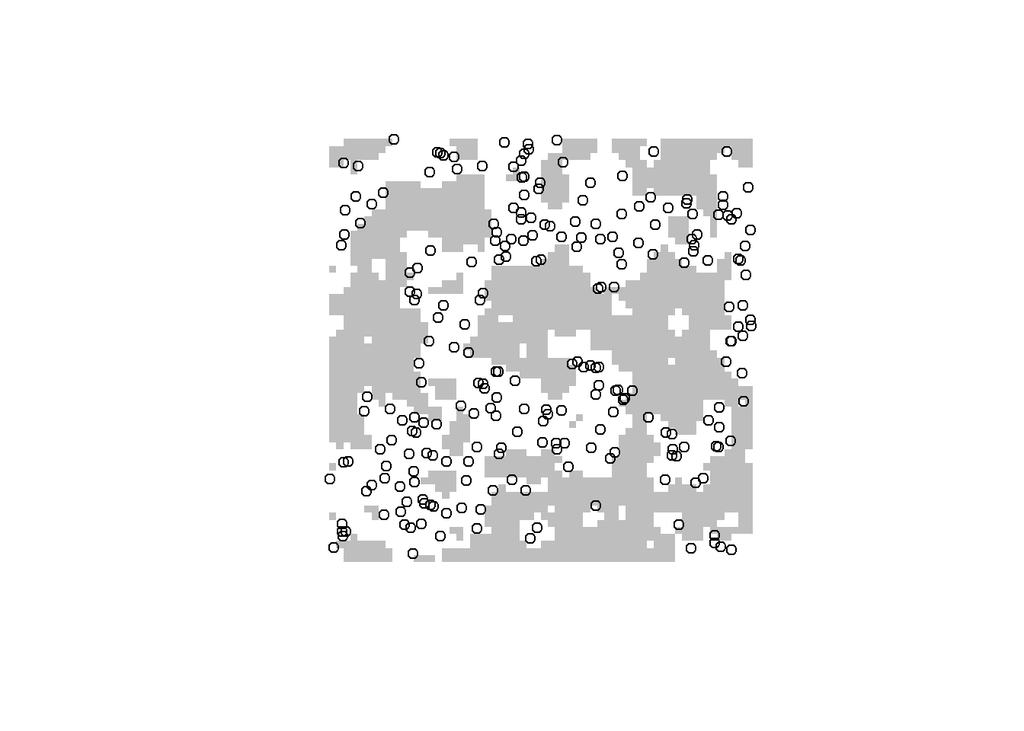

```r
Di <- randomDensity(grid144mask,  parm = parm1, plt = TRUE, border = 1,
    breaks = c(0,10,10000), col=c('grey','white'), legend = FALSE)
pop <- sim.popn(D = Di, grid144mask, model2D = 'IHP')
plot(pop, add = TRUE, frame = FALSE)
```

Fig. 1. Realisation of random habitat mosaic from `randomDensity` (white) with one point simulation.

## `randomGaussian`

This function generates an intensity surface as a log-gaussian random field using RFsimulate from the RandomFields package (Schlather et al. 2015).

Parameter ‘var’ is the variance of *in situ* log intensity. Mean log intensity ($\mu$) is computed as log(D) - var/2.

Parameter ‘scale’ is the spatial scale of the exponential covariance function.

```r
parm2 <- list(D = D, var = 0.25, scale = 5)
Di <- randomGaussian(grid144mask,  parm = parm2, plt = TRUE, border = 1)
```

```
## New output format of RFsimulate: S4 object of class 'RFsp';
## for a bare, but faster array format use 'RFoptions(spConform=FALSE)'.
```

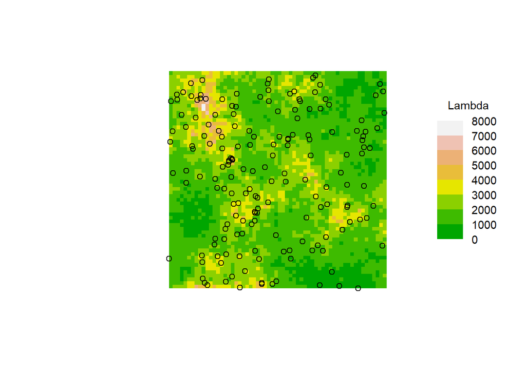

```r
pop <- sim.popn(D = Di, grid144mask, model2D = 'IHP')
plot(pop, add = TRUE, frame = FALSE)
```

Fig. 2. Realisation of log-gaussian density surface from `randomGaussian` with one point simulation.

## `randomParents`

This function generates an intensity surface from the distribution of parents for one realisation of a Thomas process.

Parameter ‘mu’ is the expected number of offspring per parent.

Parameter ‘scale’ is the spatial scale of the circular bivariate normal scatter of offspring around the parent.

The surface is derived from the **spatstat** function `rThomas` with argument ‘saveLambda = TRUE’.

```r
parm3 <- list(D = D, mu = 8, scale = 2)
Di <- randomParents(grid144mask,  parm = parm3, plt = TRUE, parentcex = 0.6,
                    border = 5)
```

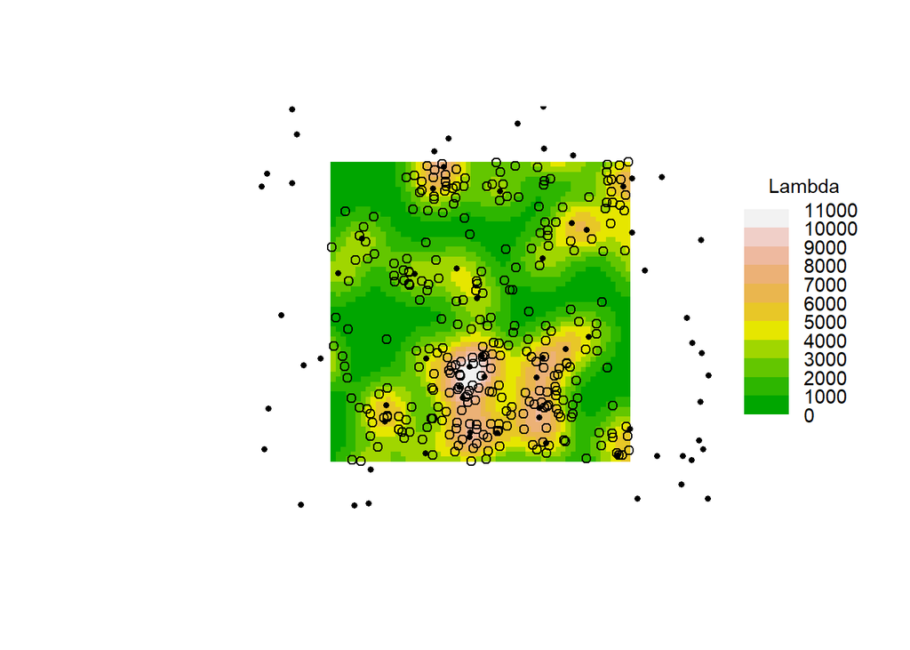

```r
pop <- sim.popn(D = Di, grid144mask, model2D = 'IHP')
plot(pop, add = TRUE, frame = FALSE)
```

Fig. 3. Realisation of density surface from `randomParents` with one point simulation. Parent locations are shown as filled dots.

# Parameter combinations

The function `carray` makes it easy to see how varying parameters of the Cox process affect overdispersion.

```r
parmlevels <- list(D = D, mu = 2^(0:5), scale = c(1e-04, 1, 2, 4, 8))
RFSargs <- list (
    randomfn   = randomParents,
    nrepl      = 1000,
    traps      = grid144,
    mask       = grid144mask,
    detectfn   = 'HHN',
    detectpar  = detectpar,
    noccasions = 5)
ca <- carray (parmlevels, RFSargs)
```

```
## Completed in 6.99 minutes at 15:58:31 12 Nov 2023
```

```r
round(ca,1)
```

```
##     scale
## mu   1e-04    1    2    4    8
##   1    1.9  1.9  1.8  1.6  1.4
##   2    2.9  2.7  2.7  2.4  1.9
##   4    4.7  4.6  4.2  3.3  2.6
##   8    8.5  7.8  7.8  6.5  4.4
##   16  15.6 14.6 13.4 11.5  7.5
##   32  30.2 30.7 27.6 21.5 15.0
```

# References

Baddeley, A. and Turner, R. (2005) spatstat: An R package for analyzing spatial point patterns. *Journal of Statistical Software* **12**, 1–42. DOI: 10.18637/jss.v012.i06

Borchers, D. L. and Efford, M. G. (2008) Spatially explicit maximum likelihood methods for capture–recapture studies. *Biometrics* **64**, 377–385.

Efford, M. G. (2023). secr: Spatially explicit capture–recapture models. R package version 4.6.5. [https://CRAN.R-project.org/package=secr/](https://cran.r-project.org/package=secr/)

Mller, J., and Waagepetersen, R. P. (2004) Statistical inference and simulation for spatial point processes. Chapman & Hall/CRC.

Saura, S. and Martinez-Millan, J. (2000) Landscape patterns simulation with a modified random clusters method. *Landscape Ecology*, **15**, 661–678.

Schlather, M., Malinowski, A., Menck, P. J., Oesting, M. and Strokorb, K. 2015. Analysis, simulation and prediction of multivariate random fields with package RandomFields. *Journal of Statistical Software*, **63**, 1–25. URL https://www.jstatsoft.org/v63/i08/.

[^1]: Package RandomFields is not currently on CRAN. It may be installed with this code: `install.packages("RandomFields", repos = c("https://spatstat.r-universe.dev", "https://cloud.r-project.org"))`